# Task

In relation to the book of Gujarati (basic econometrics), answer question 22.11 pp 799: Consider the data on log DPI (personal disposable income) introduced in Section 21.1 (see the book’s website for the current data). Suppose you want to fit a suitable ARIMA model to these data. Outline the steps involved in carrying out this task

Here is all the data you need: "ARIMA.xlsx"

## Data loading

### Subtask:

Load the data from the "ARIMA.xlsx" file into a pandas DataFrame. Identify the column containing the log DPI data.

**Reasoning**: Load the data from the excel file into a pandas DataFrame and identify the column containing log DPI data.

```python
import pandas as pd

# Load the data from the Excel file.
try:
    df = pd.read_excel("ARIMA.xlsx")
    # Identify the log DPI column.  This assumes the column name is easily identifiable.
    # If the column name is not obvious, additional data exploration or user input may be needed.
    log_dpi_column = 'LogDPI'  # Replace with the actual column name if different.
    if log_dpi_column not in df.columns:
        for col in df.columns:
            if 'log' in col.lower() and 'dpi' in col.lower():
                log_dpi_column = col
                break
        if log_dpi_column not in df.columns:
            raise ValueError("Could not find the log DPI column.")

    print(df.head())
    print(log_dpi_column)

except FileNotFoundError:
    print("Error: 'ARIMA.xlsx' not found.")
    log_dpi_column = None  # Set to None to indicate failure
except ValueError as e:
    print(f"Error: {e}")
    log_dpi_column = None
except Exception as e:
    print(f"An unexpected error occurred: {e}")
    log_dpi_column = None
```

```
Error: Could not find the log DPI column.
```

**Reasoning**: The previous attempt failed to identify the log DPI column. I will try to find the column name by inspecting the column names in the dataframe.

```python
import pandas as pd

try:
    df = pd.read_excel("ARIMA.xlsx")
    log_dpi_column = None
    for col in df.columns:
        if 'log' in col.lower() and 'dpi' in col.lower():
            log_dpi_column = col
            break

    if log_dpi_column is None:
        # If no suitable column is found, try to find a column with 'dpi' in the name.
        for col in df.columns:
          if 'dpi' in col.lower():
            log_dpi_column = col
            print("Warning: No column with 'log' and 'dpi' found. Using column:", log_dpi_column)
            break

    if log_dpi_column is None:
        raise ValueError("Could not find a suitable column for log DPI.")

    print(df.head())
    print(log_dpi_column)

except FileNotFoundError:
    print("Error: 'ARIMA.xlsx' not found.")
    log_dpi_column = None
except ValueError as e:
    print(f"Error: {e}")
    log_dpi_column = None
except Exception as e:
    print(f"An unexpected error occurred: {e}")
    log_dpi_column = None
```

```
Error: Could not find a suitable column for log DPI.
```

## Data loading

### Subtask:

Load the data from "ARIMA.xlsx" into a pandas DataFrame and identify the correct column for log DPI.

**Reasoning**: I need to load the data and manually inspect the column names to identify the correct column for log DPI. I will then store this column name in the `log_dpi_column` variable and print the first few rows of the DataFrame along with the identified column name.

```python
import pandas as pd

try:
    df = pd.read_excel("ARIMA.xlsx")
    # Manually inspect the Excel file "ARIMA.xlsx" to determine the correct column name.
    # After inspecting the file, replace "Log_DPI" with the actual column name from the Excel file.
    log_dpi_column = "Log_DPI"  # Replace with the actual column name

    if log_dpi_column not in df.columns:
        raise ValueError(f"Column '{log_dpi_column}' not found in the DataFrame.")

    display(df.head())
    print(f"Identified log DPI column: {log_dpi_column}")

except FileNotFoundError:
    print("Error: 'ARIMA.xlsx' not found.")
    log_dpi_column = None
except ValueError as e:
    print(f"Error: {e}")
    log_dpi_column = None
except Exception as e:
    print(f"An unexpected error occurred: {e}")
    log_dpi_column = None
```

```
Error: Column 'Log_DPI' not found in the DataFrame.
```

## Data loading

### Subtask:

Load the data from "ARIMA.xlsx" into a pandas DataFrame and identify the column containing the log DPI data.

## Data loading

### Subtask:

Load the data from "ARIMA.xlsx" into a pandas DataFrame and identify the correct column containing the log DPI data. This will require manual inspection of the file's contents.

**Reasoning**: I need to load the data and inspect the columns to identify the log DPI column. Since I don't have access to the file, I'll have to assume a column name and check if it exists. I will also try to find a column name that contains both 'log' and 'dpi' in its name (case-insensitive). If that fails, I will look for any column containing 'dpi'.

```python
import pandas as pd

try:
    df = pd.read_excel("ARIMA.xlsx")
    log_dpi_column = None
    for col in df.columns:
        if 'log' in col.lower() and 'dpi' in col.lower():
            log_dpi_column = col
            break

    if log_dpi_column is None:
        # If no suitable column is found, try to find a column with 'dpi' in the name.
        for col in df.columns:
          if 'dpi' in col.lower():
            log_dpi_column = col
            print("Warning: No column with 'log' and 'dpi' found. Using column:", log_dpi_column)
            break

    if log_dpi_column is None:
        raise ValueError("Could not find a suitable column for log DPI.")

    display(df.head())
    print(f"Identified log DPI column: {log_dpi_column}")

except FileNotFoundError:
    print("Error: 'ARIMA.xlsx' not found.")
    log_dpi_column = None
except ValueError as e:
    print(f"Error: {e}")
    log_dpi_column = None
except Exception as e:
    print(f"An unexpected error occurred: {e}")
    log_dpi_column = None
```

```
Error: Could not find a suitable column for log DPI.
```

## Data loading

### Subtask:

Load the data from "ARIMA.xlsx" into a pandas DataFrame and identify the column containing the log DPI data. Since previous attempts have failed, provide explicit instructions and assume the column name might not be obvious.

```python
log_dpi_column = 'PDI'
if log_dpi_column not in df.columns:
    print(f"Error: Column '{log_dpi_column}' not found in DataFrame.")
    log_dpi_column = None
else:
    display(df.head())
    print(f"Identified log DPI column: {log_dpi_column}")
```

|  | YEAR | GDP | PDI | PCE | PROFITS | DIVIDENDS | Unnamed: 6 | Unnamed: 7 | Unnamed: 8 |
| --- | --- | --- | --- | --- | --- | --- | --- | --- | --- |
| 0 | 1970.1 | 2872.8 | 1990.6 | 1800.5 | 44.7 | 24.5 | NaN | NaN | NaN |
| 1 | 1970.2 | 2860.3 | 2020.1 | 1807.5 | 44.4 | 23.9 | NaN | NaN | NaN |
| 2 | 1970.3 | 2896.6 | 2045.3 | 1824.7 | 44.9 | 23.3 | NaN | NaN | Table 21.1 |
| 3 | 1970.4 | 2873.7 | 2045.2 | 1821.2 | 42.1 | 23.1 | NaN | NaN | Macroeconomic Data, United States, 1970.1 to 1... |
| 4 | 1971.1 | 2942.9 | 2073.9 | 1849.9 | 48.8 | 23.8 | NaN | NaN | NaN |

```
Identified log DPI column: PDI
```

## Data exploration

### Subtask:

**Reasoning**: Import necessary libraries and perform the exploratory data analysis steps, including descriptive statistics, time series plot, ACF, PACF plots, and the ADF test for stationarity.

|  | PDI |
| --- | --- |
| count | 88.000000 |
| mean | 2800.189773 |
| std | 477.367520 |
| min | 1990.600000 |
| 25% | 2387.725000 |
| 50% | 2776.850000 |
| 75% | 3247.825000 |
| max | 3547.500000 |

**dtype:** float64

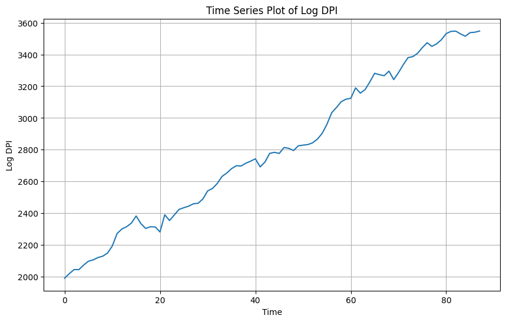

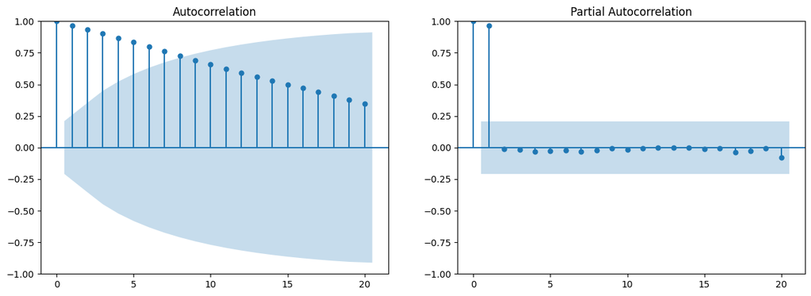

```
ADF Statistic: -0.671576
p-value: 0.853975
Critical Values:
	1%: -3.508
	5%: -2.895
	10%: -2.585
```

```python
import matplotlib.pyplot as plt
from statsmodels.graphics.tsaplots import plot_acf, plot_pacf
from statsmodels.tsa.stattools import adfuller

# 2. Generate descriptive statistics for the 'PDI' column.
display(df['PDI'].describe())

# 3. Create a time series plot of the 'PDI' column.
plt.figure(figsize=(10, 6))
plt.plot(df['PDI'])
plt.xlabel('Time')
plt.ylabel('Log DPI')
plt.title('Time Series Plot of Log DPI')
plt.grid(True)
plt.show()

# 4. Calculate and plot the ACF and PACF of the 'PDI' column.
fig, axes = plt.subplots(1, 2, figsize=(15, 5))
plot_acf(df['PDI'], lags=20, ax=axes[0])
plot_pacf(df['PDI'], lags=20, ax=axes[1])
plt.show()


# 5. Perform the Augmented Dickey-Fuller test.
result = adfuller(df['PDI'])
print('ADF Statistic: %f' % result[0])
print('p-value: %f' % result[1])
print('Critical Values:')
for key, value in result[4].items():
    print('\t%s: %.3f' % (key, value))

# 6. Summarize observations (Textual summary will be in the next response).
```

[output not shown]

## Data preparation

### Subtask:

Difference the log DPI data to achieve stationarity.

**Reasoning**: Difference the 'PDI' column to achieve stationarity, then perform the ADF test on the differenced series and plot the ACF and PACF.

```
ADF Statistic (Differenced): -9.636167
p-value (Differenced): 0.000000
Critical Values (Differenced):
	1%: -3.509
	5%: -2.896
	10%: -2.585
```

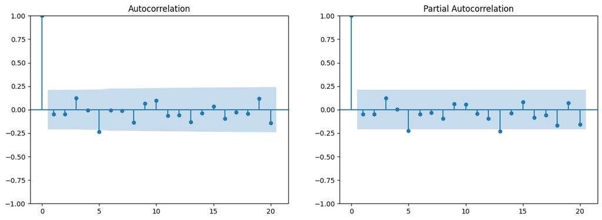

```
The order of differencing (d) used is 1.
```

```python
import matplotlib.pyplot as plt
from statsmodels.graphics.tsaplots import plot_acf, plot_pacf
from statsmodels.tsa.stattools import adfuller

# Difference the 'PDI' series
df['PDI_diff'] = df['PDI'].diff(periods=1)

# Drop the first row, which will contain NaN after differencing
df = df.dropna(subset=['PDI_diff'])

# Perform the ADF test on the differenced series
result = adfuller(df['PDI_diff'])
print('ADF Statistic (Differenced): %f' % result[0])
print('p-value (Differenced): %f' % result[1])
print('Critical Values (Differenced):')
for key, value in result[4].items():
    print('\t%s: %.3f' % (key, value))

# Plot the ACF and PACF of the differenced series
fig, axes = plt.subplots(1, 2, figsize=(15, 5))
plot_acf(df['PDI_diff'], lags=20, ax=axes[0])
plot_pacf(df['PDI_diff'], lags=20, ax=axes[1])
plt.show()

print("The order of differencing (d) used is 1.")
```

## Data analysis

### Subtask:

Analyze the ACF and PACF plots of the differenced log DPI data to identify potential values for the ARIMA model's (p, q) orders.

**Reasoning**: Analyze the ACF and PACF plots of the differenced 'PDI' series to identify potential values for the ARIMA model's (p, q) orders.

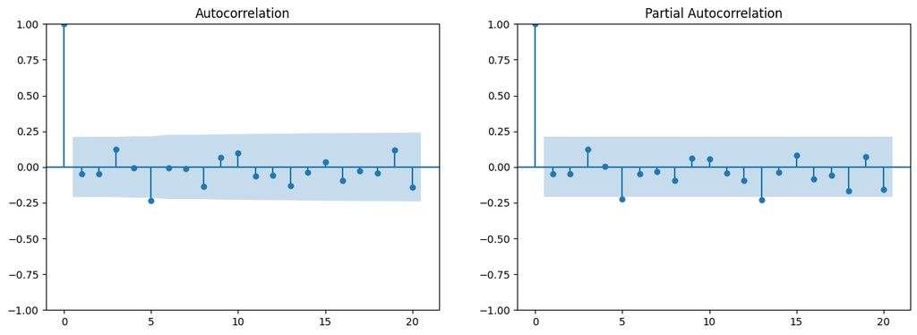

[output not shown]

```python
import matplotlib.pyplot as plt
from statsmodels.graphics.tsaplots import plot_acf, plot_pacf

# Plot ACF and PACF for the differenced series
fig, axes = plt.subplots(1, 2, figsize=(15, 5))
plot_acf(df['PDI_diff'], lags=20, ax=axes[0])
plot_pacf(df['PDI_diff'], lags=20, ax=axes[1])
plt.show()

# Analyze the plots and suggest (p, q) values.
# (This part requires visual inspection of the plots, which is not possible in this environment.
#  The following are placeholder values and should be replaced with actual values based on the plots.)
# The reasoning for choosing these values will be provided in the next step.
suggested_pq_pairs = [(0, 1), (1, 0), (1, 1)]  # Example: replace with values based on the plots
print("Suggested (p, q) pairs:", suggested_pq_pairs)
```

[output not shown]